# PocketCoder-A1

# PocketCoder-A1: How I Made My Claude Work Three Shifts

> AI doesn’t replace people, people just work more. So let’s at least make AI work at night.

It so happens that I pay 100 euros a month for Claude Code. A hefty sum that evaporates almost instantly when your account becomes a testing ground of 10+ projects, 7-8 mine and 2-3 my wife’s.

Sharing a subscription is an expensive habit, but I don’t mind.

It so happens that I’ve become somewhat dependent on building projects with Claude — I constantly want to create something in it. It’s not that I have a light workload at my day job — not at all. It’s just that the ease of building projects on Opus 4.6 and the expensive subscription provoke my brain to load the AI 24/7. It gets absurd — before bed I try to prepare task drafts that I plan to tackle tomorrow, squeezing Claude for tokens on analysis and project study. The kind of thing I try to avoid during the day, because I might hit the usage limit.

It was during one of these planning sessions that I thought — damn, it would be great to set up Claude so I could write tasks and it would finish them overnight, not just plan like I’m doing now. And ideally, it would also verify its own results.

That’s how **PocketCoder-A1** was born: an autonomous coding agent with verification, a web dashboard, and multi-provider support. 7086 lines of Python, 15 modules, zero frameworks.

1. Why this even exists
2. What is PocketCoder-A1
3. Architecture
4. Case study: epotos-templates
5. Dashboard: 8 pages, no frameworks
6. Conclusions and what’s next

## 1. Why this even exists

Actually, my thinking went even further, although I sat down to build the first mockups the very evening the idea hit me.

Here’s the idea. I’m working on one project while thoughts about another keep spinning in my head: “need to add a DeepSeek provider”, “rewrite the config”, “write tests”.

I tried OpenClaw. It didn’t work — even with a good model, nothing came together at all. Maybe I connected it wrong, maybe something else, but the result was zero. I could honestly write a separate article about those guys, because not a single project, not even a simple website parser, worked for me on it.

So I decided to build my own. The idea is simple: write tasks, go for a walk or sleep, come back to results. The agent works in sessions, saves state, picks up the next task automatically. After each session it runs real verification: pytest, py_compile, file checks on disk. A web dashboard shows what’s happening in real time. Primary provider is Claude Max, plus Claude API and Ollama as experimental.

Built primarily for myself. I actually use this already, but I put it in open source — maybe someone else will find it useful too.

## 2. What is PocketCoder-A1

Let me decode the strange letter A in the name. It stands for Autonomous. And 1, as in first version. Who knows, maybe it’ll take off and I’ll need to write updates.

CLI + web dashboard. Installation:

```bash
pip install pocketcoder-a1
```

Initialize on any project:

```bash
pca init /path/to/your-project
pca ui
```

Dashboard opens at `http://localhost:7331`. Add tasks, press Start Agent, the agent works autonomously.

**Requirements:** Python 3.10+, [Claude Code CLI](https://docs.anthropic.com/en/docs/claude-code) (`npm i -g @anthropic-ai/claude-code`).

| Attribute | Value |
| --- | --- |
| Lines of code | 7086 |
| Modules | 15 |
| Dashboard pages | 8 |
| API endpoints | 24 |
| Providers | 3 |
| E2E tests | 6/6 |

How it differs from PocketCoder v1 (my [previous project](https://habr.com/ru/articles/991022/)): v1 is a CLI agent for local models, interactive. A1 is an autonomous task manager + executor. Press a button, walk away. A completely different product. Maybe in the future I’ll figure out how to merge them.

And yes, an update for the regular PocketCoder is coming soon!

## 3. Architecture

The entire project is 15 Python modules. Zero frameworks. HTTP server on standard `http.server`, JSON via standard `json`, files via `pathlib`. The only external dependencies are `playwright` for E2E tests and optionally `anthropic` / `ollama` for alternative providers.

### 3.1 The full picture

Here’s how the system works end-to-end, from `pca start` to completion:

[figure not shown]

Full agent loop

The agent starts, captures a baseline (validation snapshot BEFORE work), builds a prompt, works through Claude CLI, parses results in real time, verifies. If everything passes, it accepts the result. If not, it injects errors into the next session and tries again. Let’s break down each piece.

### 3.2 Claude CLI as subprocess

The core of the system is launching Claude CLI as a subprocess. Sounds simple, but this is where the sneakiest problems were hiding.

[figure not shown]

Claude CLI subprocess: flags, parsing, callback

The final launch code:

```python
import os, subprocess

env = os.environ.copy()
env.pop("CLAUDECODE", None)  # without this, nested sessions crash

proc = subprocess.Popen(
    ["claude", "-p", prompt,
     "--dangerously-skip-permissions",
     "--no-session-persistence",
     "--max-turns", "25",
     "--verbose",
     "--output-format", "stream-json"],
    cwd=str(project_dir),
    env=env,
    stdout=subprocess.PIPE,
    stderr=subprocess.STDOUT,
    text=True,
    bufsize=1,
)
```

Why exactly like this? Claude Code sets `CLAUDECODE=1` in the environment. The subprocess inherits this, the inner `claude` sees the variable and crashes: “cannot launch inside another session”. Fix is one line, `env.pop`. Finding the cause took 2 hours because the error didn’t show up in stdout.

Another undocumented quirk: `--output-format stream-json` without `--verbose` just goes silent. Nothing. Another 2 hours to figure that out.

| Flag | Why |
| --- | --- |
| `-p prompt` | Non-interactive mode |
| `--dangerously-skip-permissions` | Auto-approve all tool_use |
| `--no-session-persistence` | Don’t pollute session history |
| `--max-turns 25` | Prevents infinite execution |
| `--verbose` | Required with stream-json + -p |
| `--output-format stream-json` | NDJSON stream instead of buffering |

With `stream-json`, Claude outputs NDJSON, one JSON object per line:

```json
{"type":"assistant","message":{"content":[{"type":"tool_use","name":"Read","input":{"file_path":"/src/app.py"}}]}}
{"type":"rate_limit_event","usage":{"input_tokens":12400,"output_tokens":3200}}
{"type":"result","result":"Task completed successfully."}
```

The parser classifies each event and sends it to the dashboard. `tool_use` named `Read` becomes type “read” (blue), `Bash` becomes “bash” (purple), `thinking` becomes yellow. 8 icon types total.

### 3.3 Verification: “Don’t trust, verify”

The most important part of the system. While testing, the agent would prematurely write “completed”. Meaning it made 1-2 requests and decided — that’s enough, the AI considers its job done. There’s actually an explanation for this. When you make a request via API, it’s 1 request = 1 response. But when a request comes from the web, the system under the hood automatically does minimal reasoning, and in some cases may pull its own custom skills (instructions for working more efficiently with certain modules. Very popular for Excel/Word, but actually not just those).

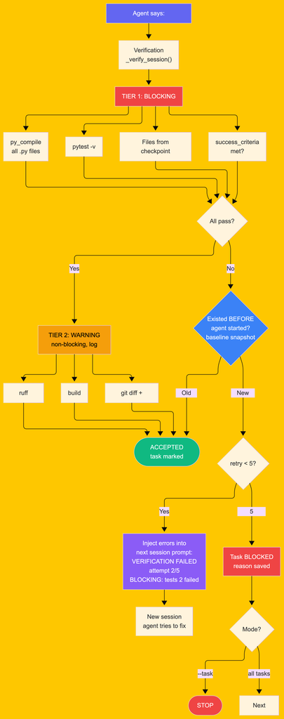

Three-tier verification

When the agent says “COMPLETED”, we don’t believe it. A three-tier check kicks in.

**Tier 1, BLOCKING.** If any check fails, the session is rejected: `py_compile` on all .py files, `pytest`, check that files actually exist on disk, check `success_criteria` from the task.

**Tier 2, WARNING.** Results are only logged: `ruff`, `build`, `git diff`.

**Tier 3, ANTI-LOOP.** Protection against infinite cycles. We’re burning tokens here, but at least efficiently :) Before the first session we capture a baseline, a snapshot of all pre-existing issues. Old bugs don’t count. If the agent can’t fix a problem in 5 attempts, the task is marked BLOCKED and the agent moves to the next one. On retry, errors are injected directly into the prompt: “VERIFICATION FAILED, attempt 2/5, BLOCKING: tests 2 failed”.

### 3.4 Providers

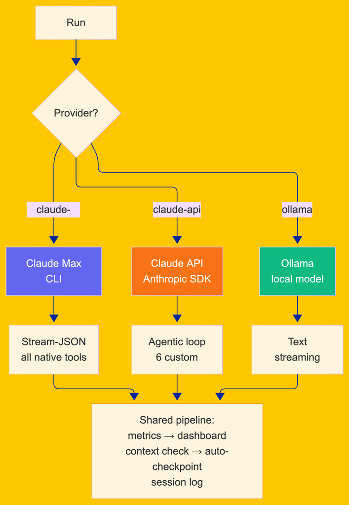

Three providers, shared pipeline

| Provider | How it works | Requires |
| --- | --- | --- |
| claude-max | CLI subprocess, Stream-JSON, all native tools | Claude Max subscription |
| claude-api | Anthropic SDK, agentic loop, 6 tools | API key |
| ollama | Text streaming, no tool calling | Local Ollama |

Claude Max is the primary. And I’ll be honest — the other providers are in a very raw state. I’m not used to asking for help, but if the project concept interests you — please help get them into proper shape :) I’m not sure I can manage on my own.

### 3.5 Real-time data flow

[figure not shown]

Data flow: agent, dashboard, browser

Claude CLI outputs NDJSON, the parser in `loop.py` puts it in `AGENT_LOG_BUFFER`, AJAX `/api/log` picks it up every 2 seconds, browser renders it. Metrics flow in parallel: `rate_limit_event` updates `_session_metrics`, `/api/status` serves them every 3 seconds to 6 cards. Timer ticks via JavaScript every second.

### 3.6 Task lifecycle

[figure not shown]

Tasks: creation, priorities, states

Three ways to create a task. CLI via `pca task add`. Quick Add form on the dashboard. Or AI Transform, where you type raw text and AI breaks it into structured tasks with priorities and criteria. Priorities change via drag-and-drop. States: PENDING, IN PROGRESS, DONE or BLOCKED.

## 4. Case study: epotos-templates

A real case. epotos-templates is an internal tool for a company — you feed it raw text, a sample presentation, or a document, and it generates reusable templates from them. The app runs on a local Ollama instance. We needed to add a second LLM provider (DeepSeek) so users could switch between models depending on the task. I wrote down my thoughts in free form and launched A1.

### Step 1: Empty page, 5 tasks in 30 seconds

I open the dashboard. Tasks page is empty:

[figure not shown]

Empty tasks page

Instead of manually formulating tasks, I use AI Transform. I just type raw text: “I want to clone epotos-templates, check how providers are configured, add a block for switching from llama to deepseek…”

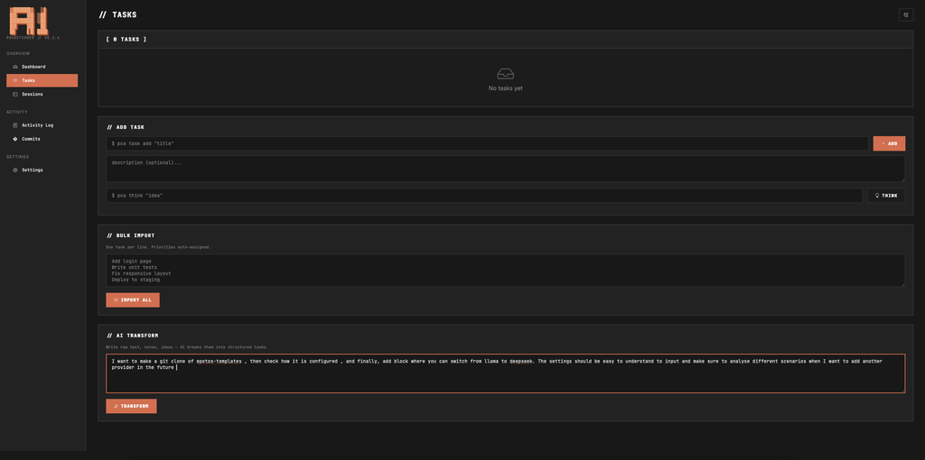

Typing text into AI Transform

I press Transform:

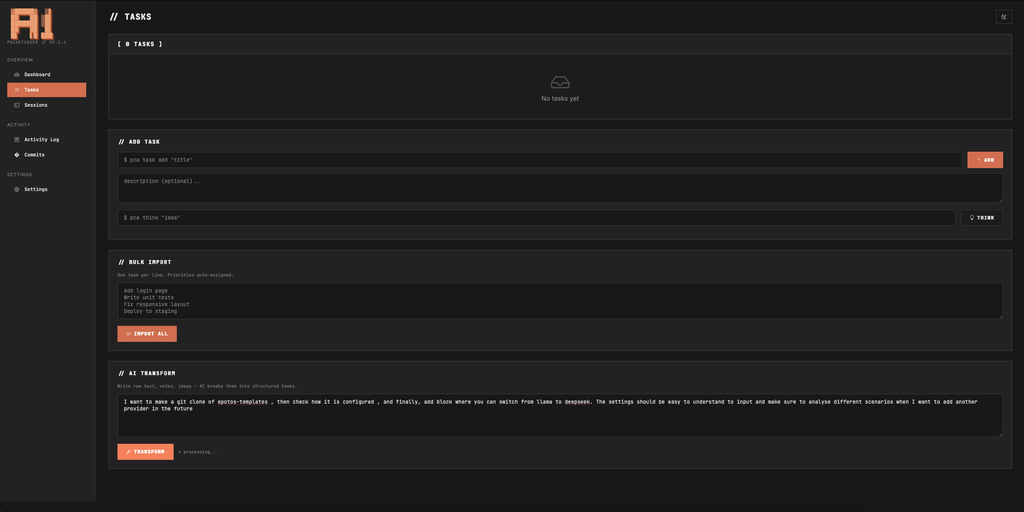

Processing

A few seconds later — 5 structured tasks with descriptions and success criteria:

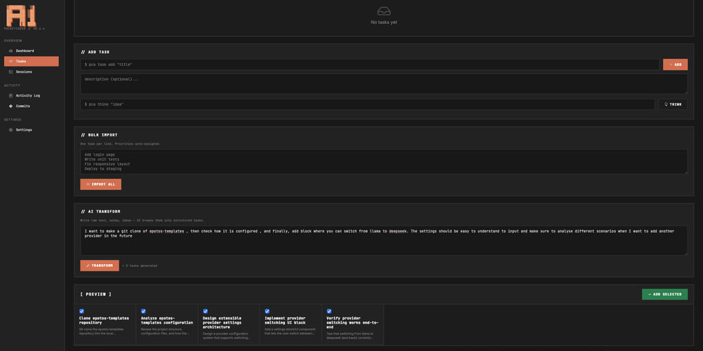

Preview of 5 tasks

I click “Add Selected”, tasks created with priorities #1-#5:

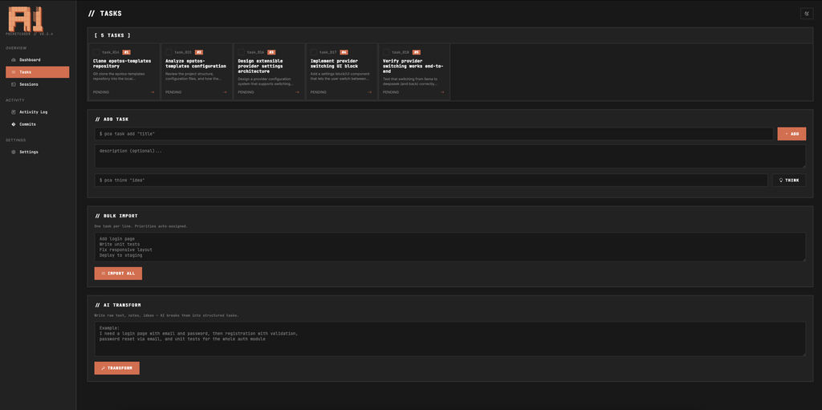

5 tasks created

### Step 2: Launch

Dashboard. 0/5 tasks, IDLE. I press Start Agent:

[figure not shown]

Dashboard before start

First task details before work begins:

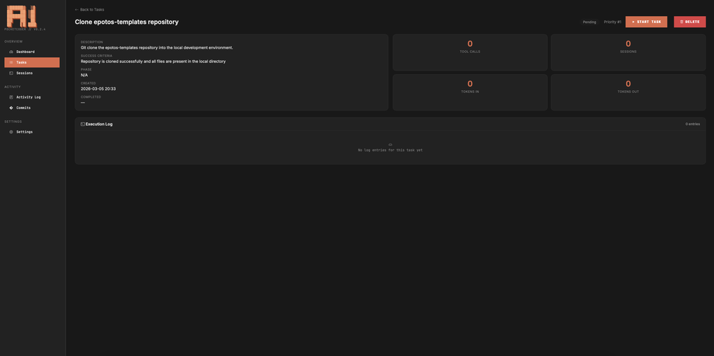

Task detail

Settings — selecting claude-api, entering API key:

[figure not shown]

Provider settings

### Step 3: Agent working

Log lines appear in real time. THINK, BASH, READ:

[figure not shown]

Agent working, live log

Task Detail: 11 tool calls, log filling up:

[figure not shown]

Task detail, agent working

### Step 4: First result

1/5 tasks done. Green checkmark. Agent automatically moved to the next one:

[figure not shown]

1 task done

Agent analyzing the codebase — reading ollama.ts, ai-client.ts, grepping localhost:11434:

[figure not shown]

Codebase analysis

### Step 5: Progress

2/5 tasks done, task_016 in progress:

[figure not shown]

2 done, 1 in progress

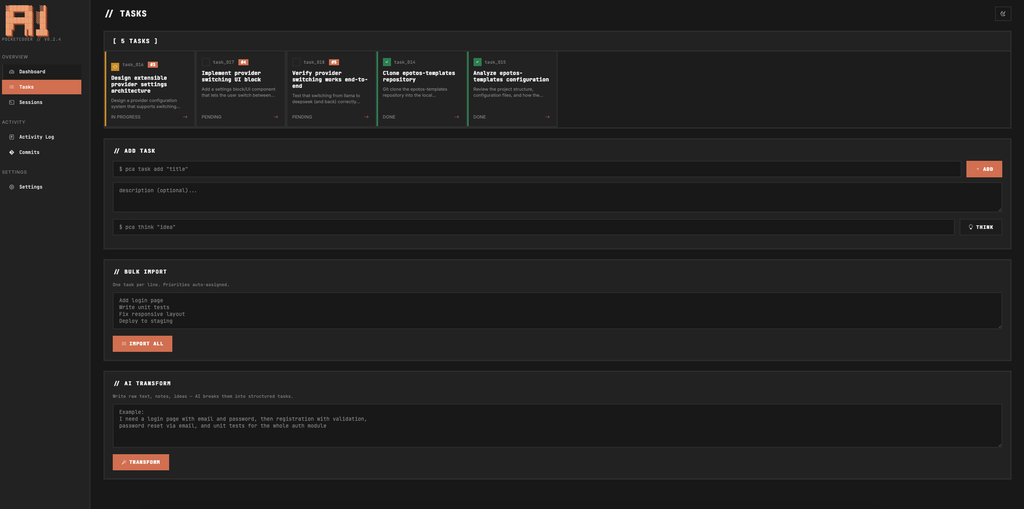

Clean view

Agent designing provider architecture:

[figure not shown]

Designing architecture

### Step 6: Message to agent

While the agent works, I type in the “Message to Agent” form — I want it to write documentation too:

[figure not shown]

Typing a message

Message queued, the agent will read it next session:

[figure not shown]

Message sent

### Step 7: All done

5/5 tasks! Agent still working, processing my documentation request:

[figure not shown]

5/5 tasks, agent still working

Verification passed, agent writing documentation:

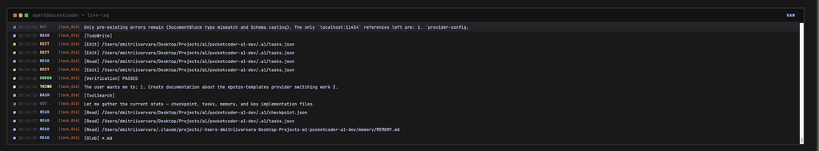

Verification + documentation

Updating CLAUDE.md, creating MEMORY.md:

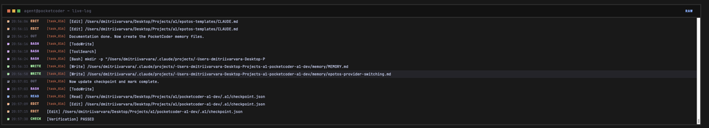

Writing documentation

### Final

COMPLETED. 5/5 tasks, 12 sessions, 23 files modified:

[figure not shown]

COMPLETED

### Light theme

The dashboard works in both themes:

[figure not shown]

Tasks, light

[figure not shown]

Dashboard, light

[figure not shown]

Log, light

[figure not shown]

Task detail, light

## 5. Dashboard

3491 lines of pure Python. No React, no Vue, no Flask. Standard `http.server` + `string.Template`. All CSS, JavaScript and HTML in one file.

### 8 pages

| Page | URL | What it does |
| --- | --- | --- |
| Dashboard | `/` | 6 metric cards, Start/Stop, live log, Quick Add |
| Tasks | `/tasks` | Task list + drag-and-drop + bulk add + AI Transform |
| Task Detail | `/task/{id}` | Full view + logs + metrics + Start/Stop/Delete |
| Sessions | `/sessions` | Session history with metrics |
| Activity Log | `/log` | Action timeline |
| Settings | `/settings` | Provider, API key, parameters |
| Commits | `/commits` | Git history with type icons |
| Transform | `/transform` | Raw text, AI, tasks |

### 6 metric cards

| Card | Data |
| --- | --- |
| Tasks | `2/5 done` + progress bar |
| Session | `#3` + WORKING/IDLE/COMPLETED |
| Tokens | `12.4K in / 3.2K out` + context progress |
| Cost | `$0.08` per session |
| Duration | `48s` (live timer, ticks every second) |
| Files | `3 modified` |

The log is styled like macOS Terminal. Dark background, monospace font, 8 icon types (read/edit/write/bash/thinking/text/metric/verify). Updates via AJAX every 2 seconds.

Full REST API with 24 endpoints. You can monitor from scripts:

```bash
curl http://localhost:7331/api/status | python -m json.tool
curl "http://localhost:7331/api/log?since=0" | python -m json.tool
```

## 6. Conclusions and what’s next

Autonomous sessions work: press Start, leave, come back to results. Verification actually catches the lying agent on three levels: blocking, warning, anti-loop. Dashboard shows everything in real time. Queue Message lets you write to the agent while it works.

In progress: auto-checkpoint at 70% context, git integration (branches + atomic commits), PyPI + uv release.

**PocketCoder-A1** is open source.

**GitHub:** github.com/Chashchin-Dmitry/pocketcoder-a1

I’d appreciate a follow on LinkedIn :) [Dmitrii Chashchin on LinkedIn](https://www.linkedin.com/in/dmitrii-chashchin-02844125b/)

Our website: https://bvmax.ru/ai